# Taller 2

Fundamentos de R para Ciencia de Datos en Salud

RCDS-2024-1 | InkaStats Academy

Autores/as

Percy Soto-Becerra

Anthony Ramos

Fecha de publicación

23-03-2024

## 1 Introducción

En este segundo taller del curso vamos a aprender a crear gráficos a partir de una base de datos de [Gapminder](https://www.gapminder.org/).

**Atajos de teclado sugeridos (para Microsoft):**

- `alt` + `-` $\rightarrow$ `<-` (operador **asignar**)

## 2 Instalar/cargar paquetes

Esta vez vamos a trabajar con el paquete nuevo `{ggplot}` del (meta)paquete `{tidyverse}`. Podemos instalar directamente el paquete `{ggplot}`, pero es mejor instalar `{tidyverse}` (https://www.tidyverse.org/), ya que este viene con un conjunto más grandes de paquetes que también usaremos más adelante.

El otro paquete nuevo que usaremos es `{dslabs}` cuya única función es almacenar bases de datos. Puedes ver qué bases de datos tiene y su documentación asociada en el repositorio oficial del CRAN: https://cran.r-project.org/web/packages/dslabs/index.html.

Por último, también usaremos los paquetes aprendidos en la clase previa: `{rio}` y `{here}`.

```r
library(tidyverse)  # Tiene {ggplot2}
library(dslabs)     # Tiene bases de datos: gapminder
# Cargar paquetes rio y here (escribir código)
```

Recuerden que hay varias formas de instalar paquetes de R. Una forma es usar `install.packages()`. Si utiliza `R Script` esta es una buena manera de hacerlo. Sin embargo, como estamos usando `Quarto` sugerimos no usar la función `install.packages()`. Lo mejor en este caso es escribir el código que cargue los paquetes (`library(nombre_paquete)`) y guardar el quarto para que este reconozca que existen paquetes sin instalar.

El aviso de RStudio para instalar el paquete nuevo deberá ser similar al siguiente:

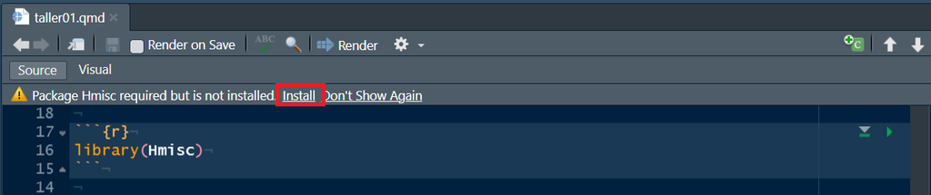

Más adelante les enseñaremos una forma completamente reproducible de instalar y cargar paquetes cuando se use `Quarto`.

**Preguntas:**

- ¿Para qué sirve el paquete `{rio}`?:
- ¿Vincule la descripción con la respectiva función? *Tip: Use ?nombre_funcion si no está seguro*.
  - Guarda datos desde R a Stata:
  - Carga datos desde Excel a R:
  - Transforma datos planos a SPSS:
  - Carga datos desde SPSS a R:
  - Transforma SPSS a Stata:
  - Guarda datos desde R a SAS:

## 3 Importación e inspección de datos

Para esta práctica, vamos a trabajar con tres bases de datos. Las dos primeras son bases da datos `juguetes` que ya se encuentran disponibles en el paquete `{dslabs}`. La última base de datos es externa, está en formato MS Excel (`*.xlsx`) y se denomina `maca_meno_perclin.xlsx`.

**Importar datos juguete:**

Los datos juguetes del paquete `{dslabs}` se pueden descargar usando la función `data()`, colocando el nombre de la base datos e indicando el paquete de procedencia.

Aquí mostramos el ejemplo de los datos `gapminder` descargados:

```r
data(gapminder, package = "dslabs")
```

Si queremos entender esta base de datos, podemos usar la función de ayuda `?` para que RStudio nos muestre la documentación en la ventana de `utilidades`, sección `Help`:

```r
?gapminder
```

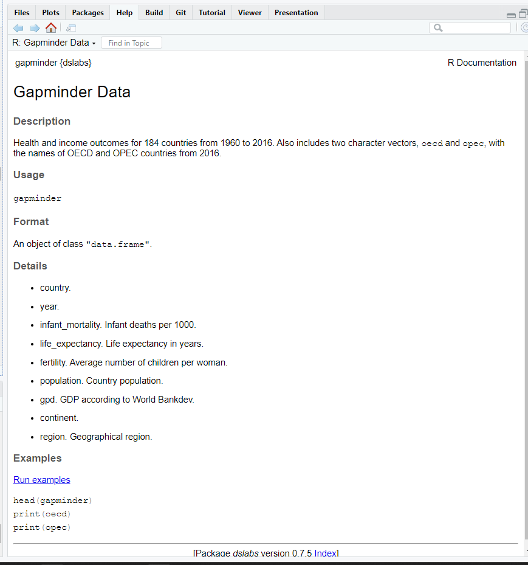

¿Cómo saber qué más bases de datos tiene el paquete `{dslabs}`? Podemos revisar la documentación del CRAN. En `Google` se puede buscar lo siguiente:

[figure not shown]

**Nota acerca de búsqueda en Google para ayuda en R**

- Es preferible usar `Rstat` en vez de `R` al buscar en Google.
- Solo hay que poner palabras claves:
  - nombre de paquete
  - nombre de función
  - qué acción se busca hacer

Una vez en el `CRAN` de R, podemos ver que tiene un `Manual de Referencia` el cual abriremos:

El enlace del manual es el siguiente: https://cran.r-project.org/web/packages/dslabs/dslabs.pdf

Si revisamos en el manual, veremos que hay diversas bases de datos. La base de datos `murders` es la que usaremos también:

```r
# cargar base de datos juguete murders
```

En la carpeta compartida tenemos el archivo de Microsoft Excel (extensión `*.xlsx`): `maca_meno_preclin.xlsx`.

```r
# Importar datos
```

## 4 Explorar datos importados

Podemos explorar los datos con dos funciones básicas: `head()` de R base y `glimpse()` de `{tidyverse}`.

- Veamos para el caso de los datos `murders`:

```r
head(murders)
```

```
       state abb region population total
1    Alabama  AL  South    4779736   135
2     Alaska  AK   West     710231    19
3    Arizona  AZ   West    6392017   232
4   Arkansas  AR  South    2915918    93
5 California  CA   West   37253956  1257
6   Colorado  CO   West    5029196    65
```

```r
glimpse(murders)
```

```
Rows: 51
Columns: 5
$ state      <chr> "Alabama", "Alaska", "Arizona", "Arkansas", "California", "…
$ abb        <chr> "AL", "AK", "AZ", "AR", "CA", "CO", "CT", "DE", "DC", "FL",…
$ region     <fct> South, West, West, South, West, West, Northeast, South, Sou…
$ population <dbl> 4779736, 710231, 6392017, 2915918, 37253956, 5029196, 35740…
$ total      <dbl> 135, 19, 232, 93, 1257, 65, 97, 38, 99, 669, 376, 7, 12, 36…
```

- Hagamos lo mismo para gapminder

```r
# Escribir código aquí
```

- Y para maca_data:

```r
# Escribir código aquí
```

**Preguntas:**

- ¿Qué hace la función `head()`?
- ¿Cuántas filas y columnas tienen los datos `gapminder`?
- ¿La columna tratamiento en qué data frame está?
- ¿Con qué código podemos extraer la columna `peso_final`?
- ¿Con qué código puedo guardar la columna extraida en un vector llamado `peso_final`?

## 5 Visualización de datos con ggplot

### 5.1 Secuencia para crear gráficos con R:

**Paso 1**

### Creemos el objeto ggplot

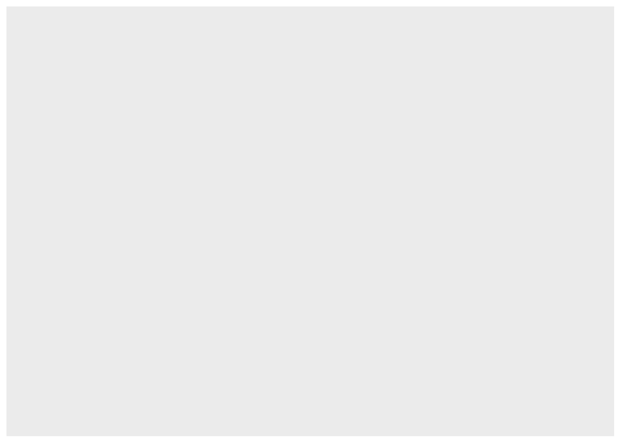

```r
ggplot(murders)
```

**Paso 2**

### Creemos la primera capa: ‘aesthetic mapping’

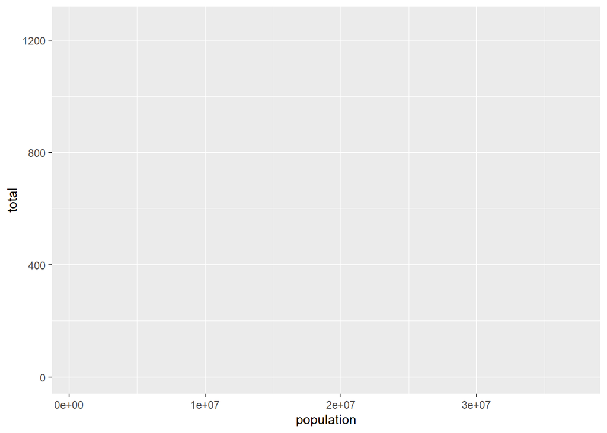

```r
ggplot(murders, aes(x = population, y = total))
```

**Paso 3**

### Creemos la segunda capa: ‘geoms’ (geometrías)

- Una sola capa de puntos:

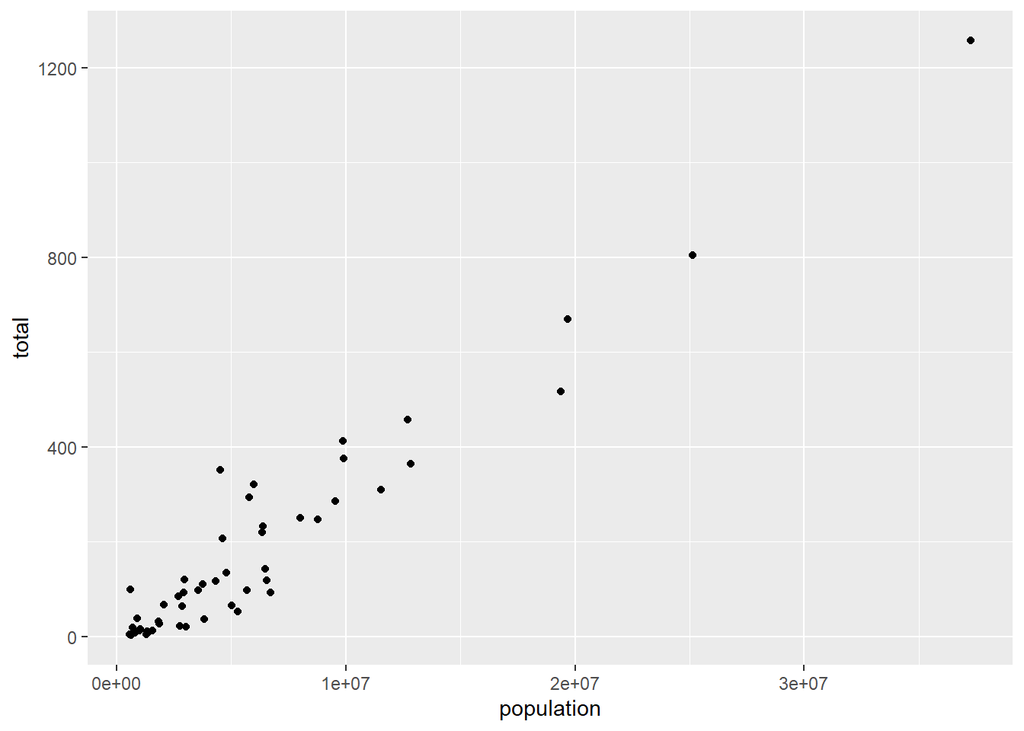

```r
ggplot(murders, aes(x = population, y = total)) +
  geom_point() # Puntos
```

- Una sola capa de líneas:

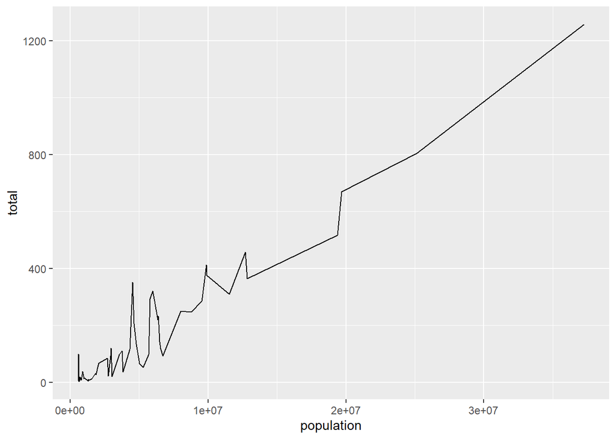

```r
ggplot(murders, aes(x = population, y = total)) +
  geom_line() # Líneas
```

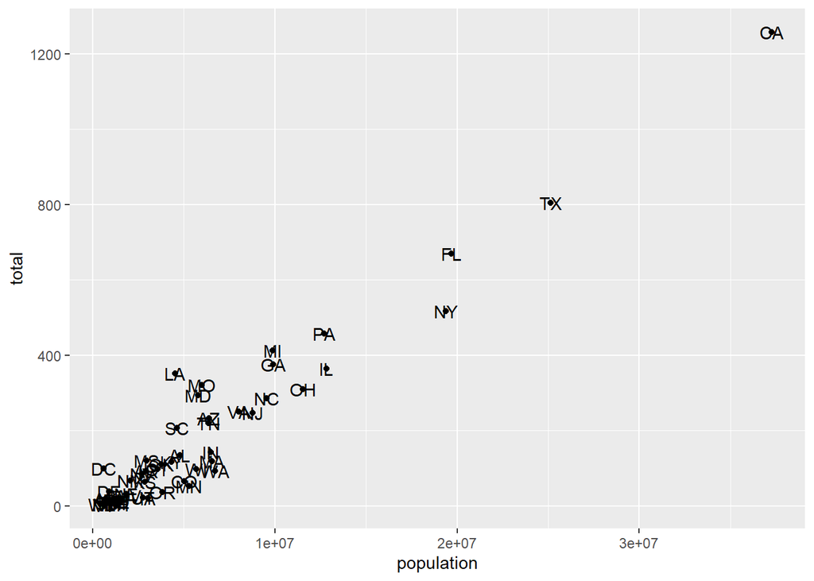

```r
ggplot(murders, aes(x = population,
                    y = total,
                    label = abb)) +
  geom_point() +
  geom_text()
```

**Paso 4**

### Retoques en `aes` y `geoms`

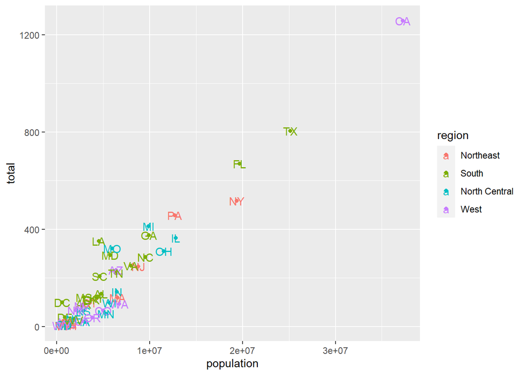

```r
ggplot(murders, aes(x = population,
                    y = total,
                    label = abb,
                    color = region)) +
  geom_point() +
  geom_text()
```

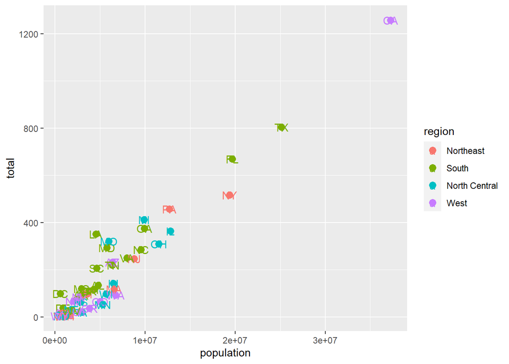

```r
ggplot(murders, aes(x = population,
                    y = total,
                    label = abb,
                    color = region)) +
  geom_point(size = 3) +
  geom_text()
```

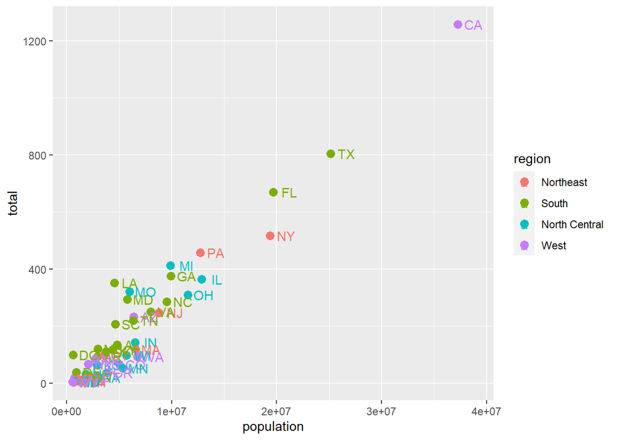

```r
ggplot(murders,  aes(x = population,
                     y = total,
                     label = abb,
                     color = region)) +
  geom_point(size = 3) +
  geom_text(nudge_x = 1500000)
```

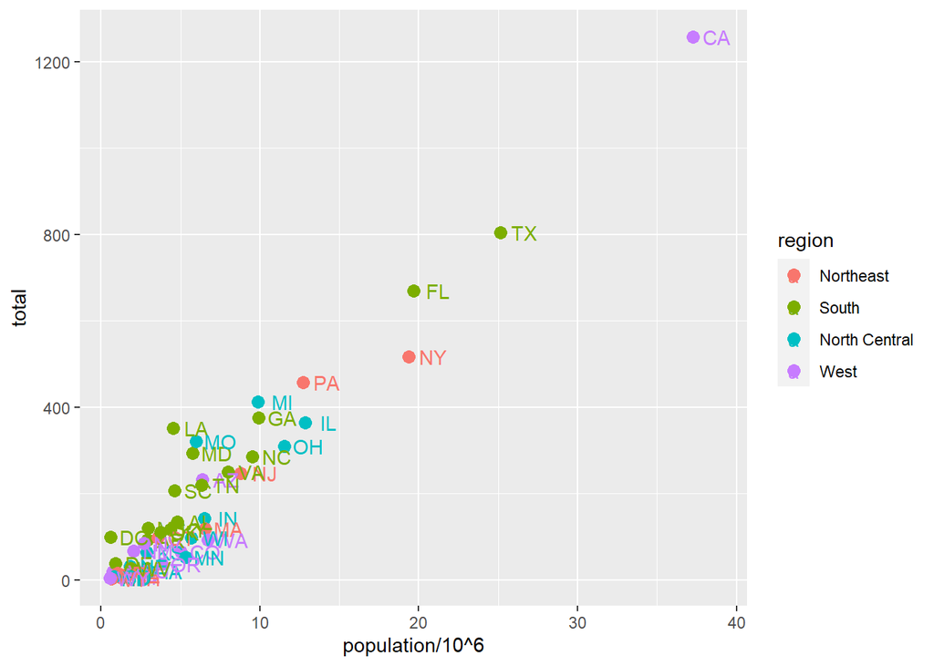

```r
ggplot(murders, aes(x = population / 10 ^ 6,
                    y = total,
                    label = abb,
                    color = region)) +
  geom_point(size = 3) +
  geom_text(nudge_x = 1.5)
```

Los argumentos de la función `ggplot()` son los siguientes:

```r
ggplot(data = murders, mapping = aes(x = population, y = total))
```

Sin embargo, si mantenemos el orden de los argumentos, podemos no escribir el nombre del argumento y escribir una versión más simplificada:

```r
ggplot(murders, aes(x = population, y = total))
```

También podemos hacer saltos de código sin que la estructura y función se rompan:

```r
ggplot(murders,
       aes(x = population,
           y = total))
```

## 6 Ejercicios

### Ejercicio 1

Crear un gráfico de puntos que muestre cómo la mortalidad infantil ha cambiado a través del tiempo.

```r
# Escribir código aquí
```

**Salto de línea con + de ggplot()**

- Cuando escribes código uno puede optar por escribir todo en una sola línea:

```r
ggplot(datos, aes(x = var1, y = var2)) + geom_point()
```

- Sin embargo, en R se recomienda realizar saltos de línea para que el código sea más claro y ordenado.
- Cuando el salto de línea ocurre dentro de un comando escrito en `ggplot()`, este debe ser hecho después del signo `+`:

```r
# Esto es correcto
ggplot(datos, aes(x = var1, y = var2)) +
    geom_point()
```

- Es erróneo hacerlo antes del signo más

```r
# Esto está mal
ggplot(datos, aes(x = var1, y = var2))
    + geom_point()
```

### Ejercicio 2

Crear un gráfico de puntos que muestre cómo la esperanza de vida ha cambiado a través del tiempo y que cada continente tenga un color distinto. Guarde el gráficos como grafico1. Imprímalo.

```r
# Escribir código aquí
```

### Ejercicio 3

En grafico1 ahora que *x* tenga la etiqueta “Años”, *y* tenga la etiqueta “Esperanza de vida” y el título sea “Esperanza de vida en el tiempo”. Guardelo como graico2 e imprimalo.

```r
# Escribir código aquí
```

### Ejercicio 4

Crear un gráfico de dispersión con datos del año 1990 de las variables fertilidad y esperanza de vida. Guarda el grafico como data90

```r
# Este código filtra 1990. La próxima clase lo estudiaremos
data_1990 <- gapminder %>%
  filter(year == 1990)
```

```r
# Escribir código aquí
```

### Ejercicio 5

```r
# Escribir código aquí
```

### Ejercicio 6

Crear un gráfico de puntos que cruce las variables fertilidad(eje x) y esperanza de vida(eje y) solo del continente americano. Además, que cada region del continente tenga un color distinto.

```r
# Este código filtra Américas. La próxima clase lo estudiaremos
data_americas <- gapminder %>%
  filter(continent == "Americas")
```

```r
# Escribir código aquí
```

### Ejercicio 7

Cambie los temas completos de los gráficos ggplot. Elija 3 temas que le gusten de esta página web: https://ggplot2.tidyverse.org/reference/ggtheme.html

- Tema 1 de elección:

```r
# Escribir código aquí
```

- Tema 2 de elección:

```r
# Escribir código aquí
```

- Tema 3 de elección:

```r
# Escribir código aquí
```

### Ejercicio 8

Con los datos `maca_datos`, cree un gráfico de cajas que compare a la glucosa entre los niveles de tratamiento. Haga que el color dependa del tratamiento. Busque la geometría apropiada para este tipo de gráfico en el siguiente enlace: https://ggplot2.tidyverse.org/reference/

```r
# Escribir código aquí
```

### Ejercicio 9

- Con el gráfico anterior, agregue una geometría de puntos:

```r
# Escribir código aquí
```

- ¿Qué pasaría si agrego la geometría de puntos primero y la de cajas después? Discuta con sus compañeros las diferencias encontradas y el por qué de estas.

```r
# Escribir código aquí
```

### Ejercicio 10

Elija un tema que le guste y agréguelo al gráfico. Edite las etiquetas correspondientes de los ejes, títulos, leyendas, etc.

```r
# Escribir código aquí
```

## 7 Renderizar

Renderice todo el Quarto.